# New Tasks

Martin Freisehner & Wilma Weixelbaum

June 5, 2018

- **Task 17** Choose a (first) model for a predictor. Clearly state your modelling assumptions and any decisions you made also during the foramting of the data, e.g.
  - use only results after 90 minutes.
  - use only data after 1994
  - which identifier was used to merge the data sets.

Since the data availability varies between data sets, clearly state how you want to fit and evaluate your predictor. The availability of the selected data sets is as follows:

```
- Historic WC data is available since the 1930s
- FIFA ranks are available since 1993,
- the full player's data is available for the 2018 world cup only,
- the market value of a player is available since 2006.
```

For other sources of data the availability might be different. Thus, we need a good strategy for bulding a classifier and evaluating it.

If you want to use information such as scored goals, caps, etc. for every player, then the only possiblity would be the qualifiers. Where can be obtain the results?

```r
# create MW stats
getMwStats <- function() {

  gk_positions <- c('Torwart')
  def_positions <- c('Innenverteidiger', 'Linker Verteidiger', 'Rechter Verteidiger', 'Abwehr', 'Libero')
  mid_positions <- c('Defensives Mittelfeld', 'Zentrales Mittelfeld', 'Offensives Mittelfeld', 'Linkes Mittelfeld', 'Rechtes Mittelfeld', 'Mittelfeld')
  atk_positions <- c('Linksaußen', 'Rechtsaußen', 'Mittelstürmer', 'Hängende Spitze', 'Sturm')

  #add position group
  team.info <- team.info %>%
    mutate(Position.Grp = ifelse(Position %in% gk_positions, "GK",
                          ifelse(Position %in% def_positions, "DEF",
                          ifelse(Position %in% mid_positions, "MID",
                          ifelse(Position %in% atk_positions, "ATK", "NA")))))
  # add mw rank
  team.info <- team.info %>%
    group_by(Year) %>%
    mutate(Market.Value.Rank = rank(desc(Market.Value), ties.method="min"))

  # add mw position rank
  team.info <- team.info %>%
    group_by(Year, Position.Grp) %>%
    mutate(Market.Value.GroupRank = rank(desc(Market.Value), ties.method="min"))

  #no info for 2002
  team.info[team.info$Year==2002,]$Market.Value.Rank <- NaN
  team.info[team.info$Year==2002,]$Market.Value.GroupRank <- NaN

  num_features <- 6

  top_23 <- team.info %>%
    group_by(Year, Team) %>%
    arrange(desc(Market.Value)) %>%
    slice(1:23) %>%
    summarize(sum_mv = sum(Market.Value, na.rm=TRUE),
              avg_mv = mean(Market.Value, na.rm=TRUE),
              avg_mv_rank = mean(Market.Value.Rank, na.rm=TRUE),
              avg_mv_grp_rank = mean(Market.Value.GroupRank, na.rm=TRUE)
              #avg_age = mean(Age, na.rm=TRUE),
              #avg_height = mean(Height, na.rm=TRUE),
              #avg_caps = mean(Caps, na.rm=TRUE),
              #avg_goals = mean(Goals, na.rm=TRUE),
              #avg_goal_rate = mean(Goals, na.rm=TRUE)/mean(Caps, na.rm=TRUE)
              )
  colnames(top_23)[3:num_features] <- paste("top_23_", colnames(top_23)[3:num_features], sep="")

  top_11 <- team.info %>%
    group_by(Year, Team) %>%
    arrange(desc(Market.Value)) %>%
    slice(1:11) %>%
    summarize(sum_mv = sum(Market.Value, na.rm=TRUE),
              avg_mv = mean(Market.Value, na.rm=TRUE),
              avg_mv_rank = mean(Market.Value.Rank, na.rm=TRUE),
              avg_mv_grp_rank = mean(Market.Value.GroupRank, na.rm=TRUE)
              #avg_age = mean(Age, na.rm=TRUE),
              #avg_height = mean(Height, na.rm=TRUE),
              #avg_caps = mean(Caps, na.rm=TRUE),
              #avg_goals = mean(Goals, na.rm=TRUE),
              #avg_goal_rate = mean(Goals, na.rm=TRUE)/mean(Caps, na.rm=TRUE)
              )
  colnames(top_11)[3:num_features] <- paste("top_11_", colnames(top_11)[3:num_features], sep="")

  top_5_def <- team.info %>%
    filter(Position.Grp == "DEF") %>%
    group_by(Year, Team) %>%
    arrange(desc(Market.Value)) %>%
    slice(1:5) %>%
    summarize(sum_mv = sum(Market.Value, na.rm=TRUE),
              avg_mv = mean(Market.Value, na.rm=TRUE),
              avg_mv_rank = mean(Market.Value.Rank, na.rm=TRUE),
              avg_mv_grp_rank = mean(Market.Value.GroupRank, na.rm=TRUE)
              #avg_age = mean(Age, na.rm=TRUE),
              #avg_height = mean(Height, na.rm=TRUE),
              #avg_caps = mean(Caps, na.rm=TRUE),
              #avg_goals = mean(Goals, na.rm=TRUE),
              #avg_goal_rate = mean(Goals, na.rm=TRUE)/mean(Caps, na.rm=TRUE)
              )
  colnames(top_5_def)[3:num_features] <- paste("top_5_def_", colnames(top_5_def)[3:num_features], sep="")

  top_5_mid <- team.info %>%
    filter(Position.Grp == "MID") %>%
    group_by(Year, Team) %>%
    arrange(desc(Market.Value)) %>%
    slice(1:5) %>%
    summarize(sum_mv = sum(Market.Value, na.rm=TRUE),
              avg_mv = mean(Market.Value, na.rm=TRUE),
              avg_mv_rank = mean(Market.Value.Rank, na.rm=TRUE),
              avg_mv_grp_rank = mean(Market.Value.GroupRank, na.rm=TRUE)
              #avg_age = mean(Age, na.rm=TRUE),
              #avg_height = mean(Height, na.rm=TRUE),
              #avg_caps = mean(Caps, na.rm=TRUE),
              #avg_goals = mean(Goals, na.rm=TRUE),
              #avg_goal_rate = mean(Goals, na.rm=TRUE)/mean(Caps, na.rm=TRUE)
              )
  colnames(top_5_mid)[3:num_features] <- paste("top_5_mid_", colnames(top_5_mid)[3:num_features], sep="")

    top_5_att <- team.info %>%
    filter(Position.Grp == "ATK") %>%
    group_by(Year, Team) %>%
    arrange(desc(Market.Value)) %>%
    slice(1:5) %>%
    summarize(sum_mv = sum(Market.Value, na.rm=TRUE),
              avg_mv = mean(Market.Value, na.rm=TRUE),
              avg_mv_rank = mean(Market.Value.Rank, na.rm=TRUE),
              avg_mv_grp_rank = mean(Market.Value.GroupRank, na.rm=TRUE)
              #avg_age = mean(Age, na.rm=TRUE),
              #avg_height = mean(Height, na.rm=TRUE),
              #avg_caps = mean(Caps, na.rm=TRUE),
              #avg_goals = mean(Goals, na.rm=TRUE),
              #avg_goal_rate = mean(Goals, na.rm=TRUE)/mean(Caps, na.rm=TRUE)
              )
    colnames(top_5_att)[3:num_features] <- paste("top_5_att_", colnames(top_5_att)[3:num_features], sep="")

    top_gk <- team.info %>%
    filter(Position.Grp == "GK") %>%
    group_by(Year, Team) %>%
    arrange(desc(Market.Value)) %>%
    slice(1:1) %>%
    summarize(sum_mv = sum(Market.Value, na.rm=TRUE),
              avg_mv = mean(Market.Value, na.rm=TRUE),
              avg_mv_rank = mean(Market.Value.Rank, na.rm=TRUE),
              avg_mv_grp_rank = mean(Market.Value.GroupRank, na.rm=TRUE),
              #avg_age = mean(Age, na.rm=TRUE),
              avg_height = mean(Height, na.rm=TRUE)
              #avg_caps = mean(Caps, na.rm=TRUE),
              #avg_goals = mean(Goals, na.rm=TRUE),
              #avg_goal_rate = mean(Goals, na.rm=TRUE)/mean(Caps, na.rm=TRUE)
              )
    colnames(top_gk)[3:num_features+1] <- paste("top_gk_", colnames(top_gk)[3:num_features+1], sep="")

    key_players <- team.info %>%
      group_by(Year, Team) %>%
      summarize(top_3 = sum(Market.Value.GroupRank < 4, na.rm=TRUE),
                top_5 = sum(Market.Value.GroupRank < 6, na.rm=TRUE),
                top_10 = sum(Market.Value.GroupRank < 11, na.rm=TRUE),
                oa_top_11 = sum(Market.Value.Rank < 12, na.rm=TRUE))
    colnames(key_players)[3:6] <- paste("key_players_", colnames(key_players)[3:6], sep="")

    merged <- Reduce(function(x, y) merge(x,y, all=TRUE), list(top_23, top_11, top_5_def, top_5_mid, top_5_att, top_gk, key_players))
    return(merged)
}

mw.data <- getMwStats()
datatable(mw.data)
```

|  | Year | Team | top_23_sum_mv | top_23_avg_mv | top_23_avg_mv_rank | top_23_avg_mv_grp_rank | top_11_sum_mv | top_11_avg_mv | top_11_avg_mv_rank | top_11_avg_mv_grp_rank | top_5_def_sum_mv | top_5_def_avg_mv | top_5_def_avg_mv_rank | top_5_def_avg_mv_grp_rank | top_5_mid_sum_mv | top_5_mid_avg_mv | top_5_mid_avg_mv_rank | top_5_mid_avg_mv_grp_rank | top_5_att_sum_mv | top_5_att_avg_mv | top_5_att_avg_mv_rank | top_5_att_avg_mv_grp_rank | sum_mv | top_gk_avg_mv | top_gk_avg_mv_rank | top_gk_avg_mv_grp_rank | top_gk_avg_height | key_players_top_3 | key_players_top_5 | … |
| --- | --- | --- | --- | --- | --- | --- | --- | --- | --- | --- | --- | --- | --- | --- | --- | --- | --- | --- | --- | --- | --- | --- | --- | --- | --- | --- | --- | --- | --- | --- |
| 1 | 2002 | ARG | 0 | 0 |  |  | 0 | 0 |  |  | 0 | 0 |  |  | 0 | 0 |  |  | 0 | 0 |  |  | 0 | 0 |  |  | 1.88 | 0 | 0 | … |
| 2 | 2002 | BEL | 0 | 0 |  |  | 0 | 0 |  |  | 0 | 0 |  |  | 0 | 0 |  |  | 0 | 0 |  |  | 0 | 0 |  |  | 1.88 | 0 | 0 | … |
| 3 | 2002 | BRA | 0 | 0 |  |  | 0 | 0 |  |  | 0 | 0 |  |  | 0 | 0 |  |  | 0 | 0 |  |  | 0 | 0 |  |  | 1.93 | 0 | 0 | … |
| 4 | 2002 | CHN | 0 | 0 |  |  | 0 | 0 |  |  | 0 | 0 |  |  | 0 | 0 |  |  | 0 | 0 |  |  | 0 | 0 |  |  | 1.83 | 0 | 0 | … |
| 5 | 2002 | CMR | 0 | 0 |  |  | 0 | 0 |  |  | 0 | 0 |  |  | 0 | 0 |  |  | 0 | 0 |  |  | 0 | 0 |  |  | 1.8 | 0 | 0 | … |
| 6 | 2002 | CRC | 0 | 0 |  |  | 0 | 0 |  |  | 0 | 0 |  |  | 0 | 0 |  |  | 0 | 0 |  |  | 0 | 0 |  |  |  | 0 | 0 | … |
| 7 | 2002 | CRO | 0 | 0 |  |  | 0 | 0 |  |  | 0 | 0 |  |  | 0 | 0 |  |  | 0 | 0 |  |  | 0 | 0 |  |  | 1.93 | 0 | 0 | … |
| 8 | 2002 | DEN | 0 | 0 |  |  | 0 | 0 |  |  | 0 | 0 |  |  | 0 | 0 |  |  | 0 | 0 |  |  | 0 | 0 |  |  | 1.96 | 0 | 0 | … |
| 9 | 2002 | ECU | 0 | 0 |  |  | 0 | 0 |  |  | 0 | 0 |  |  | 0 | 0 |  |  | 0 | 0 |  |  | 0 | 0 |  |  | 1.83 | 0 | 0 | … |
| 10 | 2002 | ENG | 0 | 0 |  |  | 0 | 0 |  |  | 0 | 0 |  |  | 0 | 0 |  |  | 0 | 0 |  |  | 0 | 0 |  |  | 1.9 | 0 | 0 | … |

[output cut: 150 more lines]

```r
# fifa ranking
rank_years <- c(2002,2006,2010,2014,2018)
ranking.data <- fifa.ranking %>%
  select(rank, country_abrv, rank_date) %>%
  mutate(Year = format(rank_date, "%Y"), Month = format(rank_date, "%m")) %>%
  filter(Year %in% rank_years, Month < 6) %>%
  group_by(country_abrv, Year) %>%
  summarize(avg_rank = mean(rank, na.rm=TRUE),
            min_rank = min(rank, na.rm=TRUE),
            max_rank = max(rank, na.rm=TRUE))

datatable(ranking.data)
```

|  | country_abrv | Year | avg_rank | min_rank | max_rank |
| --- | --- | --- | --- | --- | --- |
| 1 | AFG | 2006 | 181.454545454545 | 173 | 189 |
| 2 | AFG | 2010 | 193.545454545455 | 189 | 196 |
| 3 | AFG | 2014 | 132.166666666667 | 122 | 143 |
| 4 | AFG | 2018 | 145.2 | 140 | 148 |
| 5 | AIA | 2002 | 195.636363636364 | 195 | 196 |
| 6 | AIA | 2006 | 197.727272727273 | 194 | 205 |
| 7 | AIA | 2010 | 202.545454545455 | 202 | 203 |
| 8 | AIA | 2014 | 206.666666666667 | 206 | 208 |
| 9 | AIA | 2018 | 206.4 | 206 | 207 |
| 10 | ALB | 2002 | 94.8181818181818 | 92 | 97 |

[output cut: 1029 more lines]

```r
# filter history to include results since 2002 as we don't care about earlier results (only vague relevance)
WC18.matches <- read.csv("wc2018.csv")
match.data <- WC.matches %>%
  filter(Year >= 2002) %>%
  select(Year, Team.Initials, Opponent.Initials, Result)

match.data  <- rbind(match.data, WC18.matches)

datatable(match.data)
```

|  | Year | Team.Initials | Opponent.Initials | Result |
| --- | --- | --- | --- | --- |
| 1 | 2002 | FRA | SEN | L |
| 2 | 2002 | URU | DEN | L |
| 3 | 2002 | IRL | CMR | D |
| 4 | 2002 | GER | KSA | W |
| 5 | 2002 | ARG | NGA | W |
| 6 | 2002 | PAR | RSA | D |
| 7 | 2002 | ENG | SWE | D |
| 8 | 2002 | ESP | SVN | W |
| 9 | 2002 | BRA | TUR | W |
| 10 | 2002 | ITA | ECU | W |

[output cut: 594 more lines]

Task 17.1 Exploration of features

```r
ranking.data <- ranking.data %>% mutate(Year=as.numeric(Year))
#assert that team names are equal in all datasets
mw.teams <- mw.data %>% distinct(Year, Team)
ranking.teams <- ranking.data %>% distinct(Year, country_abrv) %>% select (Year, Team=country_abrv)
match.teams <- match.data %>% distinct(Year, Team.Initials) %>% select (Year, Team=Team.Initials)
stopifnot(anti_join(mw.teams %>% filter(Year != 2018), match.teams) %>% summarize(n=n()) == 0)
stopifnot(anti_join(match.teams, mw.teams) %>% summarize(n=n()) == 0)
stopifnot(anti_join(match.teams, ranking.teams) %>% summarize(n=n()) == 0)
stopifnot(anti_join(mw.teams, ranking.teams) %>% summarize(n=n()) == 0)
WC.data <- left_join(match.data, mw.data, by=c("Year" = "Year", "Team.Initials" = "Team"))
WC.data <- left_join(WC.data, ranking.data, by=c("Year" = "Year", "Team.Initials" = "country_abrv"))
colnames(WC.data)[5:length(WC.data)] <- paste("team_", colnames(WC.data)[5:length(WC.data)], sep="")

# do the same for opponent
WC.data <- left_join(WC.data, mw.data, by=c("Year" = "Year", "Opponent.Initials" = "Team"))
WC.data <- left_join(WC.data, ranking.data, by=c("Year" = "Year", "Opponent.Initials" = "country_abrv"))
l_bound = 5+ (length(WC.data) -4) /2
colnames(WC.data)[l_bound:length(WC.data)] <- paste("opponent_", colnames(WC.data)[l_bound:length(WC.data)], sep="")
```

Task 17.2 Improvement for ML

As it is easier for most ML-algorithms to work on single features instead of pairwise features we store the difference from team to opponent instead of both values for all features. This behaviour can be toggled with a flag.

```r
USE_DIFFERENCES <- TRUE

if (USE_DIFFERENCES) {
  WC.data.dif <- WC.data[,1:4]
  for (k in 5:(l_bound-1)) {
    new_name <- paste0(c("dif", unlist(strsplit(colnames(WC.data)[k],"_"))[-1]), collapse="_")
    WC.data.dif[k] <- WC.data[k] - WC.data[l_bound+k-5]
    colnames(WC.data.dif)[k] <- new_name
  }
  WC.data <- WC.data.dif
  datatable(WC.data)
}
```

|  | Year | Team.Initials | Opponent.Initials | Result | dif_top_23_sum_mv | dif_top_23_avg_mv | dif_top_23_avg_mv_rank | dif_top_23_avg_mv_grp_rank | dif_top_11_sum_mv | dif_top_11_avg_mv | dif_top_11_avg_mv_rank | dif_top_11_avg_mv_grp_rank | dif_top_5_def_sum_mv | dif_top_5_def_avg_mv | dif_top_5_def_avg_mv_rank | dif_top_5_def_avg_mv_grp_rank | dif_top_5_mid_sum_mv | dif_top_5_mid_avg_mv | dif_top_5_mid_avg_mv_rank | dif_top_5_mid_avg_mv_grp_rank | dif_top_5_att_sum_mv | dif_top_5_att_avg_mv | dif_top_5_att_avg_mv_rank | dif_top_5_att_avg_mv_grp_rank | dif_sum_mv | dif_top_gk_avg_mv | dif_top_gk_avg_mv_rank | dif_top_gk_avg_mv_grp_rank | dif_top_gk_avg_height | … |
| --- | --- | --- | --- | --- | --- | --- | --- | --- | --- | --- | --- | --- | --- | --- | --- | --- | --- | --- | --- | --- | --- | --- | --- | --- | --- | --- | --- | --- | --- | --- |
| 1 | 2002 | FRA | SEN | L | 0 | 0 |  |  | 0 | 0 |  |  | 0 | 0 |  |  | 0 | 0 |  |  | 0 | 0 |  |  | 0 | 0 |  |  | 0.02 | … |
| 2 | 2002 | URU | DEN | L | 0 | 0 |  |  | 0 | 0 |  |  | 0 | 0 |  |  | 0 | 0 |  |  | 0 | 0 |  |  | 0 | 0 |  |  | -0.0600000000000001 | … |
| 3 | 2002 | IRL | CMR | D | 0 | 0 |  |  | 0 | 0 |  |  | 0 | 0 |  |  | 0 | 0 |  |  | 0 | 0 |  |  | 0 | 0 |  |  | 0.05 | … |
| 4 | 2002 | GER | KSA | W | 0 | 0 |  |  | 0 | 0 |  |  | 0 | 0 |  |  | 0 | 0 |  |  | 0 | 0 |  |  | 0 | 0 |  |  |  | … |
| 5 | 2002 | ARG | NGA | W | 0 | 0 |  |  | 0 | 0 |  |  | 0 | 0 |  |  | 0 | 0 |  |  | 0 | 0 |  |  | 0 | 0 |  |  | 0.0199999999999998 | … |
| 6 | 2002 | PAR | RSA | D | 0 | 0 |  |  | 0 | 0 |  |  | 0 | 0 |  |  | 0 | 0 |  |  | 0 | 0 |  |  | 0 | 0 |  |  | -0.0800000000000001 | … |
| 7 | 2002 | ENG | SWE | D | 0 | 0 |  |  | 0 | 0 |  |  | 0 | 0 |  |  | 0 | 0 |  |  | 0 | 0 |  |  | 0 | 0 |  |  | -0.02 | … |
| 8 | 2002 | ESP | SVN | W | 0 | 0 |  |  | 0 | 0 |  |  | 0 | 0 |  |  | 0 | 0 |  |  | 0 | 0 |  |  | 0 | 0 |  |  | -0.03 | … |
| 9 | 2002 | BRA | TUR | W | 0 | 0 |  |  | 0 | 0 |  |  | 0 | 0 |  |  | 0 | 0 |  |  | 0 | 0 |  |  | 0 | 0 |  |  | 0.0599999999999998 | … |
| 10 | 2002 | ITA | ECU | W | 0 | 0 |  |  | 0 | 0 |  |  | 0 | 0 |  |  | 0 | 0 |  |  | 0 | 0 |  |  | 0 | 0 |  |  | 0.0899999999999999 | … |

[output cut: 594 more lines]

Task 17.3 Explore good features (singular)

```r
# This makes only sense if we don't use difference-stats (because results are mirrored :-))
result_stats <- WC.data %>% group_by(Result) %>% summarise_all(funs(mean(., na.rm=TRUE)))
datatable(result_stats)
```

|  | Result | Year | Team.Initials | Opponent.Initials | dif_top_23_sum_mv | dif_top_23_avg_mv | dif_top_23_avg_mv_rank | dif_top_23_avg_mv_grp_rank | dif_top_11_sum_mv | dif_top_11_avg_mv | dif_top_11_avg_mv_rank | dif_top_11_avg_mv_grp_rank | dif_top_5_def_sum_mv | dif_top_5_def_avg_mv | dif_top_5_def_avg_mv_rank | dif_top_5_def_avg_mv_grp_rank | dif_top_5_mid_sum_mv | dif_top_5_mid_avg_mv | dif_top_5_mid_avg_mv_rank | dif_top_5_mid_avg_mv_grp_rank | dif_top_5_att_sum_mv | dif_top_5_att_avg_mv | dif_top_5_att_avg_mv_rank | dif_top_5_att_avg_mv_grp_rank | dif_sum_mv | dif_top_gk_avg_mv | dif_top_gk_avg_mv_rank | dif_top_gk_avg_mv_grp_rank | dif_top_gk_avg_height | … |
| --- | --- | --- | --- | --- | --- | --- | --- | --- | --- | --- | --- | --- | --- | --- | --- | --- | --- | --- | --- | --- | --- | --- | --- | --- | --- | --- | --- | --- | --- | --- |
| 1 | D | 2008.4 |  |  | -1308571.42857143 | -56894.4099378882 | 5.16261998870694 | 1.43083003952569 | -707857.142857143 | -64350.6493506493 | 7.84651711924439 | 1.61511216056671 | -2027619.04761905 | -405523.80952381 | 9.11428571428571 | 3.21558441558442 | -1622380.95238095 | -324476.19047619 | 11.2337662337662 | 2.92987012987013 | 1732619.04761905 | 345845.238095238 | 0.528571428571428 | -0.141558441558442 | 413333.333333333 | 413333.333333333 | 2.42857142857143 | 0.597402597402597 | -0.000927835051546393 | … |
| 2 | L | 2009.552 |  |  | -92552100 | -4015494.77382521 | 156.702036671058 | 44.5446662274923 | -65470700 | -5951881.81818182 | 138.648181818182 | 38.2913636363636 | -16937200 | -3387440 | 146.337 | 50.001 | -23617100 | -4684420 | 146.518 | 44.92525 | -33514900 | -6758581.66666667 | 162.07125 | 42.4981666666667 | -3598700 | -3598700 | 158.28 | 16.64 | -0.00655172413793103 | … |
| 3 | W | 2009.51807228916 |  |  | 114616767.068273 | 5007577.16857769 | -172.729900711286 | -49.0022418857573 | 83093775.1004016 | 7553979.55458196 | -155.934216537232 | -42.7263590680676 | 22047088.3534137 | 4409417.67068273 | -163.403015075377 | -55.7276381909548 | 29203413.6546185 | 5840682.73092369 | -164.366834170854 | -50.035175879397 | 42072088.3534137 | 8606507.69745649 | -177.824120603015 | -46.7283082077052 | 4434136.54618474 | 4434136.54618474 | -173.592964824121 | -18.5829145728643 | 0.0103030303030303 | … |

```r
# after this check we removed
# - caps-goals-goals/caps (only available for 2018)
# - age for everyone - not telling
# - height (except for GK) - not telling, for GK (L:1.877, W:1.883)
```

- **Task 18** You do not have to use a statistical model, but if you do, you have to train it. This would require a trainings dataset. This training set would need include at least
- the result of the game
- general information about the game
- information about the home team
- information about the away team

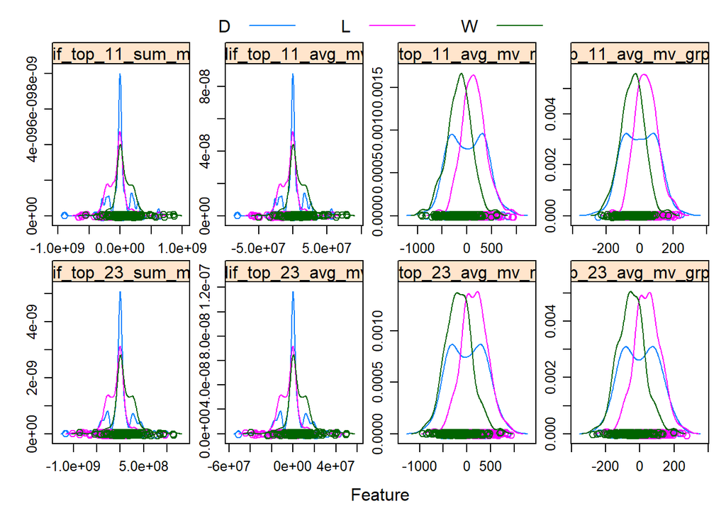

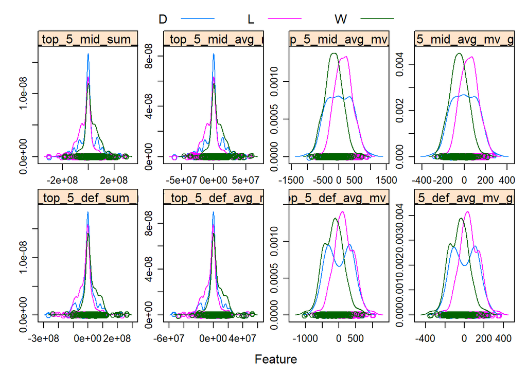

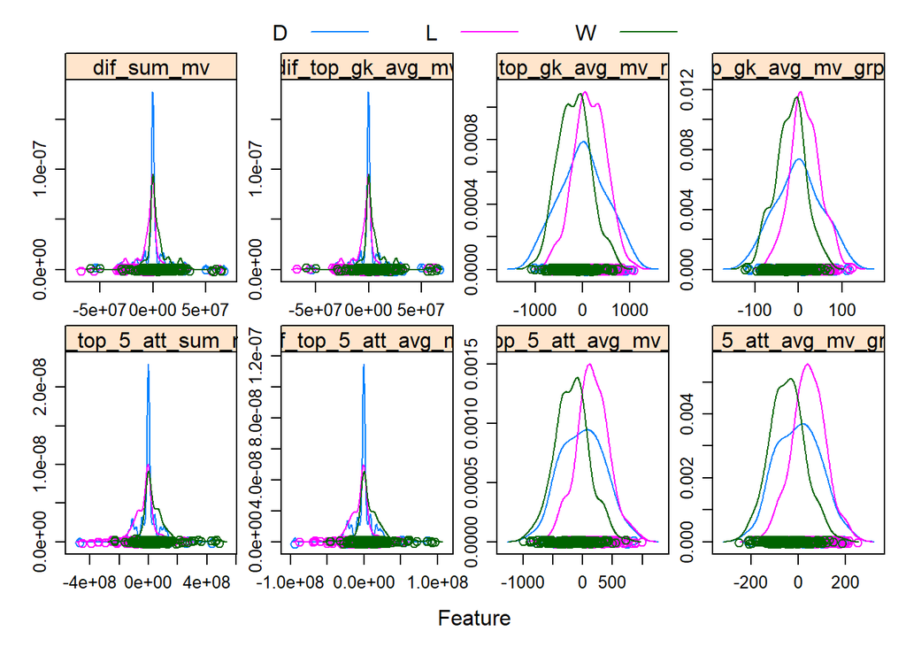

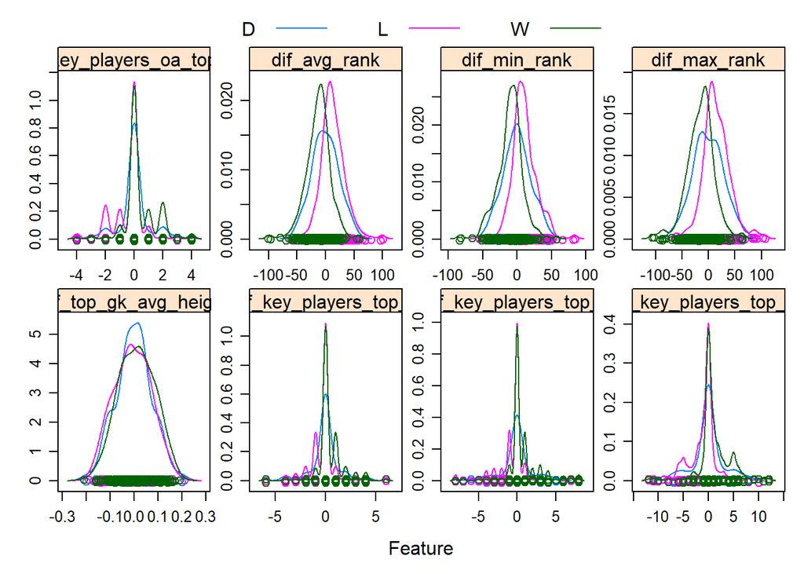

```r
WC.data$Result <- as.factor(WC.data$Result)

featurePlot(x = WC.data[-c(1:4)],
            y = WC.data$Result,
            plot="density",
            scales = list(x = list(relation="free"),
                          y = list(relation="free")),
            layout = c(4, 2),
            auto.key = list(columns = 3))
```

One Hot Encoding

```r
USE_ONE_HOT_ENCODING <- FALSE

WC.data$Team.Initials <- as.factor(WC.data$Team.Initials)
WC.data$Opponent.Initials <- as.factor(WC.data$Opponent.Initials)

temp <- WC.data

addLevel <- function(x, newlevel=NULL) {
  if(is.factor(x)) {
    if (is.na(match(newlevel, levels(x))))
      return(factor(x, levels=c(levels(x), newlevel)))
  }
  return(x)
}

WC.data$Team.Initials <- addLevel(WC.data$Team.Initials, "EGY")
WC.data$Team.Initials <- addLevel(WC.data$Team.Initials, "ISL")
WC.data$Team.Initials <- addLevel(WC.data$Team.Initials, "MAR")
WC.data$Team.Initials <- addLevel(WC.data$Team.Initials, "PAN")
WC.data$Team.Initials <- addLevel(WC.data$Team.Initials, "SEN")
WC.data$Opponent.Initials <-addLevel(WC.data$Opponent.Initials, "EGY")
WC.data$Opponent.Initials <-addLevel(WC.data$Opponent.Initials, "ISL")
WC.data$Opponent.Initials <-addLevel(WC.data$Opponent.Initials, "MAR")
WC.data$Opponent.Initials <-addLevel(WC.data$Opponent.Initials, "PAN")
WC.data$Opponent.Initials <-addLevel(WC.data$Opponent.Initials, "SEN")


#temp$Team.Initials <- factor(c(levels(temp$Team.Initials), 'EGY', 'ISL', 'MAR', 'PAN', 'SEN'))
#temp$Opponent.Initials <- factor(temp$Opponent.Initials,levels=c(sort(unique(temp$Opponent.Initials)), 'EGY', 'ISL', 'MAR', 'PAN', 'SEN'))

if (USE_ONE_HOT_ENCODING) {
  WC.data <- predict(dummyVars(~ .,data=WC.data), newdata = WC.data)
}
```

Create training/test set

```r
WC.test <- WC.data %>% filter(Year == 2014)
WC.train <- WC.data %>% filter(Year < 2014)

set.seed(122)

cl <- makePSOCKcluster(5)
registerDoParallel(cl)

fitControl <- trainControl(method = "repeatedcv",
                           number = 5,
                           repeats = 5)

WC.train$Result <- as.character(WC.train$Result)
```

GBM

```r
gbmGrid <-  expand.grid(interaction.depth = c(1,2,5),
                        n.trees = 50,
                        shrinkage = 0.1,
                        n.minobsinnode = 20)

gbmFit1 <- train(Result ~ ., data = WC.train,
                 method = "gbm",
                 trControl = fitControl,
                 tuneGrid = gbmGrid,
                 verbose = FALSE,
                 na.action = na.omit)
```

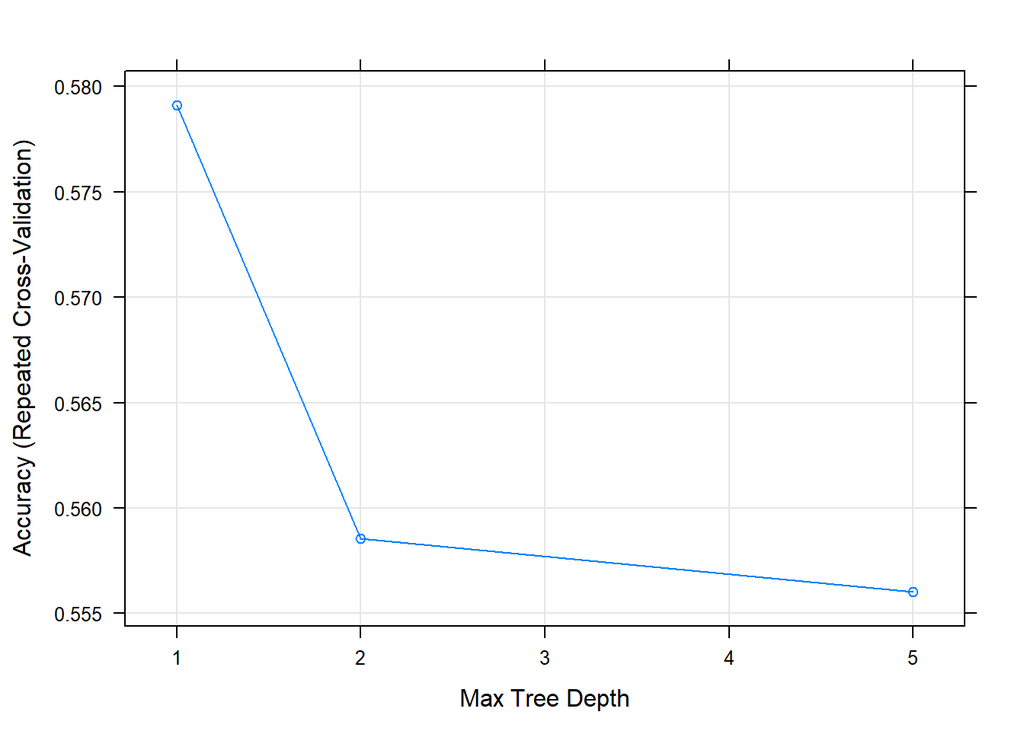

```r
plot(gbmFit1)
```

```r
gbmPred <- predict(gbmFit1, WC.test)
confusionMatrix(gbmPred, WC.test$Result)
```

```
## Confusion Matrix and Statistics
##
##           Reference
## Prediction  D  L  W
##          D  1  2  2
##          L  9 52 10
##          W  8 15 57
##
## Overall Statistics
##
##                Accuracy : 0.7051
##                  95% CI : (0.6269, 0.7753)
##     No Information Rate : 0.4423
##     P-Value [Acc > NIR] : 2.923e-11
##
##                   Kappa : 0.481
##  Mcnemar's Test P-Value : 0.02857
##
## Statistics by Class:
##
##                      Class: D Class: L Class: W
## Sensitivity           0.05556   0.7536   0.8261
## Specificity           0.97101   0.7816   0.7356
## Pos Pred Value        0.20000   0.7324   0.7125
## Neg Pred Value        0.88742   0.8000   0.8421
## Prevalence            0.11538   0.4423   0.4423
## Detection Rate        0.00641   0.3333   0.3654
## Detection Prevalence  0.03205   0.4551   0.5128
## Balanced Accuracy     0.51329   0.7676   0.7809
```

```r
#best --> depth 1 - n.trees 50
```

```r
rfFitGrid <-  expand.grid(mtry=c(1,25,50,75,100,150))

rfFit1 <- train(Result ~ ., data = WC.train,
                 method = "rf",
                 trControl = fitControl,
                 tuneGrid = rfFitGrid,
                 #verbose = FALSE,
                 na.action = na.omit)
```

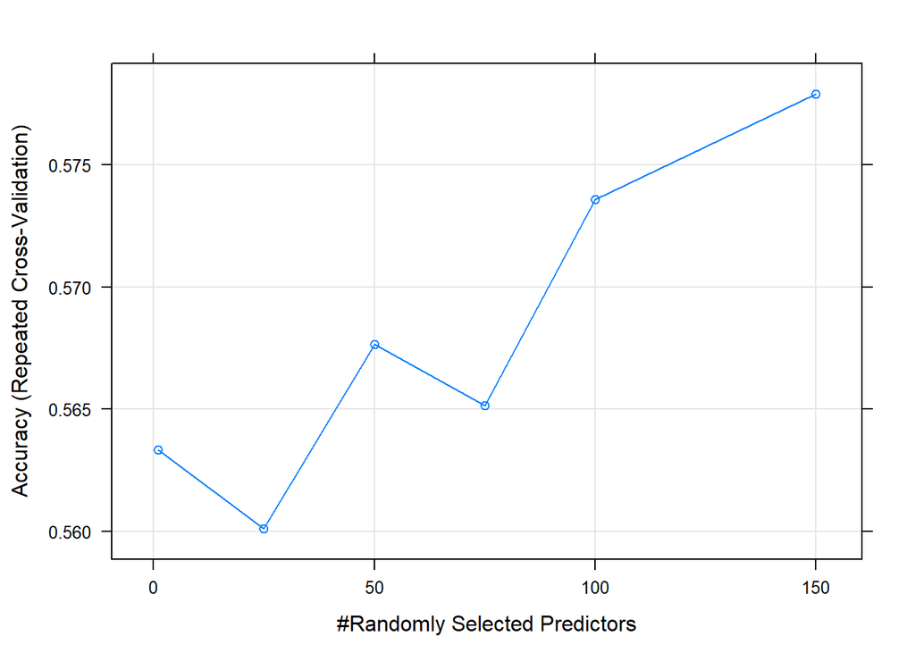

```r
plot(rfFit1)
```

```r
rfPred <- predict(rfFit1, WC.test)
confusionMatrix(rfPred, WC.test$Result)
```

```
## Confusion Matrix and Statistics
##
##           Reference
## Prediction  D  L  W
##          D  0  0  0
##          L  9 53 16
##          W  9 16 53
##
## Overall Statistics
##
##                Accuracy : 0.6795
##                  95% CI : (0.6001, 0.7519)
##     No Information Rate : 0.4423
##     P-Value [Acc > NIR] : 1.97e-09
##
##                   Kappa : 0.4253
##  Mcnemar's Test P-Value : 0.0004398
##
## Statistics by Class:
##
##                      Class: D Class: L Class: W
## Sensitivity            0.0000   0.7681   0.7681
## Specificity            1.0000   0.7126   0.7126
## Pos Pred Value            NaN   0.6795   0.6795
## Neg Pred Value         0.8846   0.7949   0.7949
## Prevalence             0.1154   0.4423   0.4423
## Detection Rate         0.0000   0.3397   0.3397
## Detection Prevalence   0.0000   0.5000   0.5000
## Balanced Accuracy      0.5000   0.7404   0.7404
```

```r
svmFitGrid <-  expand.grid(sigma=8.263708e-17,
                             C = c(0.25,0.5, 0.75,1))

svmFit <- train(Result ~ ., data = WC.train,
                 method = "svmRadial",
                 trControl = fitControl,
                 tuneGrid = svmFitGrid,
                 #verbose=FALSE,
                 na.action = na.omit)
```

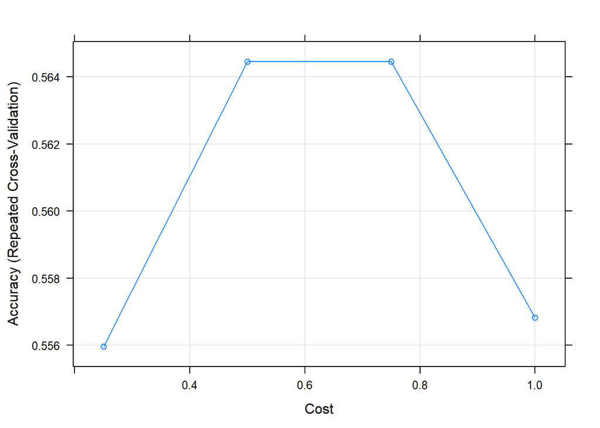

```r
plot(svmFit)
```

```r
svmPred <- predict(svmFit, WC.test)
confusionMatrix(svmPred, WC.test$Result)
```

```
## Confusion Matrix and Statistics
##
##           Reference
## Prediction  D  L  W
##          D  0  0  0
##          L  9 54 15
##          W  9 15 54
##
## Overall Statistics
##
##                Accuracy : 0.6923
##                  95% CI : (0.6135, 0.7636)
##     No Information Rate : 0.4423
##     P-Value [Acc > NIR] : 2.545e-10
##
##                   Kappa : 0.4483
##  Mcnemar's Test P-Value : 0.0004398
##
## Statistics by Class:
##
##                      Class: D Class: L Class: W
## Sensitivity            0.0000   0.7826   0.7826
## Specificity            1.0000   0.7241   0.7241
## Pos Pred Value            NaN   0.6923   0.6923
## Neg Pred Value         0.8846   0.8077   0.8077
## Prevalence             0.1154   0.4423   0.4423
## Detection Rate         0.0000   0.3462   0.3462
## Detection Prevalence   0.0000   0.5000   0.5000
## Balanced Accuracy      0.5000   0.7534   0.7534
```

```r
treebagFit <- train(Result ~ .,
                 data = WC.train,
                 method = "treebag",
                 trControl = fitControl,
                 verbose=FALSE,
                 na.action = na.omit
                 )

print(treebagFit$results)
```

```
##   parameter  Accuracy     Kappa AccuracySD    KappaSD
## 1      none 0.5671685 0.2977734 0.06219738 0.09754056
```

```r
treebagPred <- predict(treebagFit, WC.test)
confusionMatrix(treebagPred, WC.test$Result)
```

```
## Confusion Matrix and Statistics
##
##           Reference
## Prediction  D  L  W
##          D  1  1  0
##          L 10 56 19
##          W  7 12 50
##
## Overall Statistics
##
##                Accuracy : 0.6859
##                  95% CI : (0.6068, 0.7578)
##     No Information Rate : 0.4423
##     P-Value [Acc > NIR] : 7.184e-10
##
##                   Kappa : 0.441
##  Mcnemar's Test P-Value : 0.001164
##
## Statistics by Class:
##
##                      Class: D Class: L Class: W
## Sensitivity           0.05556   0.8116   0.7246
## Specificity           0.99275   0.6667   0.7816
## Pos Pred Value        0.50000   0.6588   0.7246
## Neg Pred Value        0.88961   0.8169   0.7816
## Prevalence            0.11538   0.4423   0.4423
## Detection Rate        0.00641   0.3590   0.3205
## Detection Prevalence  0.01282   0.5449   0.4423
## Balanced Accuracy     0.52415   0.7391   0.7531
```

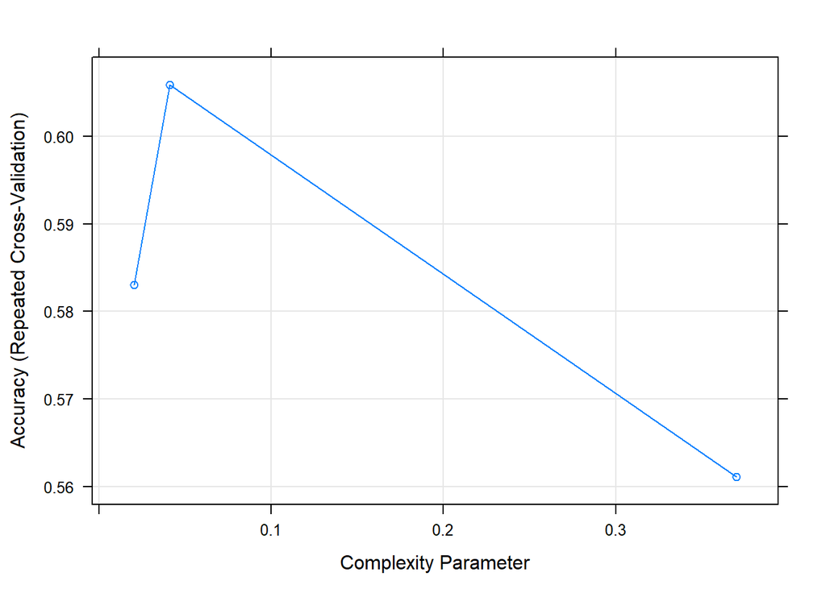

```r
rpartFitGrid <-  expand.grid(cp=c(0.02054795, 0.04109589, 0.36986301))
rpartFit <- train(Result ~ .,
                 data = WC.train,
                 method = "rpart",
                 trControl = fitControl,
                 tuneGrid = rpartFitGrid,
                 #verbose=FALSE,
                 na.action = na.omit)

plot(rpartFit)
```

```r
rpartPred <- predict(rpartFit, WC.test)
confusionMatrix(rpartPred, WC.test$Result)
```

```
## Confusion Matrix and Statistics
##
##           Reference
## Prediction  D  L  W
##          D  0  0  0
##          L  9 51 21
##          W  9 18 48
##
## Overall Statistics
##
##                Accuracy : 0.6346
##                  95% CI : (0.5539, 0.7102)
##     No Information Rate : 0.4423
##     P-Value [Acc > NIR] : 1.049e-06
##
##                   Kappa : 0.3448
##  Mcnemar's Test P-Value : 0.0003942
##
## Statistics by Class:
##
##                      Class: D Class: L Class: W
## Sensitivity            0.0000   0.7391   0.6957
## Specificity            1.0000   0.6552   0.6897
## Pos Pred Value            NaN   0.6296   0.6400
## Neg Pred Value         0.8846   0.7600   0.7407
## Prevalence             0.1154   0.4423   0.4423
## Detection Rate         0.0000   0.3269   0.3077
## Detection Prevalence   0.0000   0.5192   0.4808
## Balanced Accuracy      0.5000   0.6972   0.6927
```

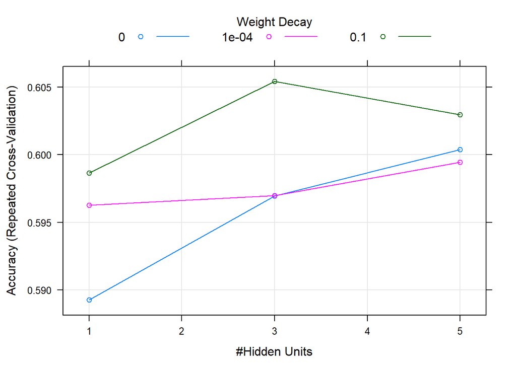

```r
avNNetGrid <-  expand.grid(size=c(1,3,5), decay=c(0e+00,1e-04,1e-01), bag = FALSE)

avNNetFit <- train(Result ~ ., data = WC.train,
                 method = "avNNet",
                 trControl = fitControl,
                 tuneGrid = avNNetGrid,
                 verbose=FALSE,
                 na.action = na.omit)

plot(avNNetFit)
```

```r
avNNetPred <- predict(avNNetFit, WC.test)
confusionMatrix(avNNetPred, WC.test$Result)
```

```
## Confusion Matrix and Statistics
##
##           Reference
## Prediction  D  L  W
##          D  0  0  0
##          L  9 56 13
##          W  9 13 56
##
## Overall Statistics
##
##                Accuracy : 0.7179
##                  95% CI : (0.6404, 0.787)
##     No Information Rate : 0.4423
##     P-Value [Acc > NIR] : 2.976e-12
##
##                   Kappa : 0.4943
##  Mcnemar's Test P-Value : 0.0004398
##
## Statistics by Class:
##
##                      Class: D Class: L Class: W
## Sensitivity            0.0000   0.8116   0.8116
## Specificity            1.0000   0.7471   0.7471
## Pos Pred Value            NaN   0.7179   0.7179
## Neg Pred Value         0.8846   0.8333   0.8333
## Prevalence             0.1154   0.4423   0.4423
## Detection Rate         0.0000   0.3590   0.3590
## Detection Prevalence   0.0000   0.5000   0.5000
## Balanced Accuracy      0.5000   0.7794   0.7794
```

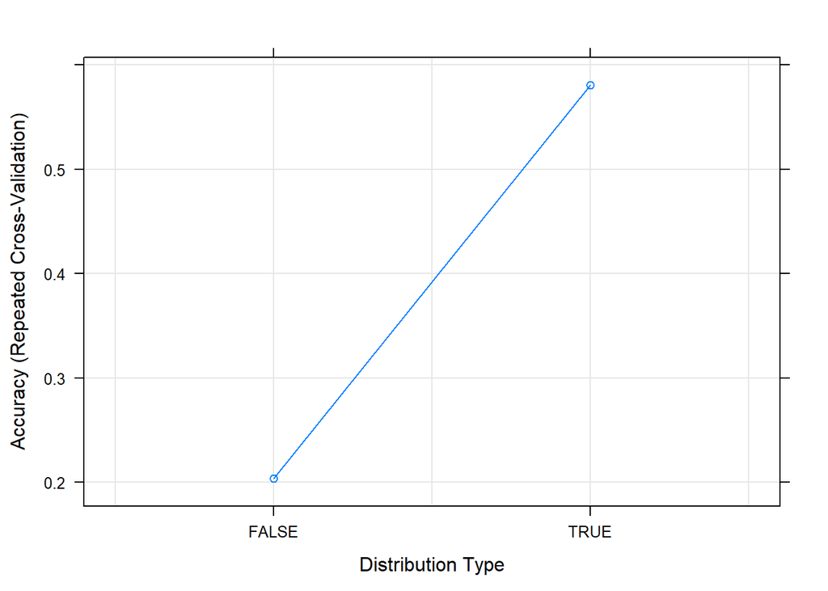

```r
nbGrid <-  expand.grid(laplace=0, usekernel=c(FALSE,TRUE), adjust=1)

nbFit <- train(Result ~ ., data = WC.train,
                 method = "naive_bayes",
                 trControl = fitControl,
                 tuneGrid = nbGrid,
                 verbose=FALSE,
                 na.action = na.omit)

plot(nbFit)
```

```r
nbPred <- predict(nbFit, WC.test)
confusionMatrix(nbPred, WC.test$Result)
```

```
## Confusion Matrix and Statistics
##
##           Reference
## Prediction  D  L  W
##          D  0  0  0
##          L  9 53 16
##          W  9 16 53
##
## Overall Statistics
##
##                Accuracy : 0.6795
##                  95% CI : (0.6001, 0.7519)
##     No Information Rate : 0.4423
##     P-Value [Acc > NIR] : 1.97e-09
##
##                   Kappa : 0.4253
##  Mcnemar's Test P-Value : 0.0004398
##
## Statistics by Class:
##
##                      Class: D Class: L Class: W
## Sensitivity            0.0000   0.7681   0.7681
## Specificity            1.0000   0.7126   0.7126
## Pos Pred Value            NaN   0.6795   0.6795
## Neg Pred Value         0.8846   0.7949   0.7949
## Prevalence             0.1154   0.4423   0.4423
## Detection Rate         0.0000   0.3397   0.3397
## Detection Prevalence   0.0000   0.5000   0.5000
## Balanced Accuracy      0.5000   0.7404   0.7404
```

```r
stopCluster(cl)
```

```r
WC18.test <- WC.data %>% filter(Year >= 2018)
WC18.train <- WC.data %>% filter(Year< 2018)

set.seed(122)

cl <- makePSOCKcluster(5)
registerDoParallel(cl)


WC18.train$Result <- as.character(WC18.train$Result)

gbmGrid <-  expand.grid(interaction.depth = c(1,2,5),
                        n.trees = 50,
                        shrinkage = 0.1,
                        n.minobsinnode = 20)

gbmFit2 <- train(Result ~ ., data = WC18.train,
                 method = "gbm",
                 trControl = fitControl,
                 tuneGrid = gbmGrid,
                 verbose = FALSE,
                 na.action = na.omit)
```

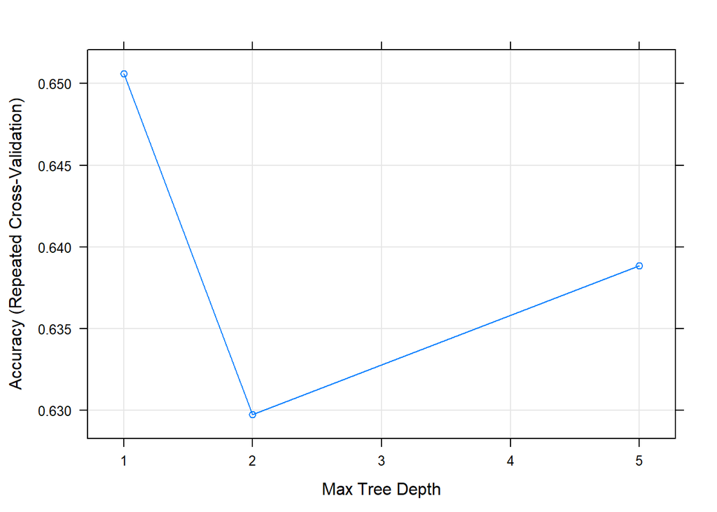

```r
plot(gbmFit2)
```

```r
gbmPred2 <- predict(gbmFit2, WC18.test, na.action=na.pass)
confusionMatrix(gbmPred2, WC18.test$Result)
```

```
## Confusion Matrix and Statistics
##
##           Reference
## Prediction  D  L  W
##          D  0  0  0
##          L  4 18  9
##          W  5 10 18
##
## Overall Statistics
##
##                Accuracy : 0.5625
##                  95% CI : (0.4328, 0.6863)
##     No Information Rate : 0.4375
##     P-Value [Acc > NIR] : 0.02987
##
##                   Kappa : 0.2332
##  Mcnemar's Test P-Value : 0.02860
##
## Statistics by Class:
##
##                      Class: D Class: L Class: W
## Sensitivity            0.0000   0.6429   0.6667
## Specificity            1.0000   0.6389   0.5946
## Pos Pred Value            NaN   0.5806   0.5455
## Neg Pred Value         0.8594   0.6970   0.7097
## Prevalence             0.1406   0.4375   0.4219
## Detection Rate         0.0000   0.2812   0.2812
## Detection Prevalence   0.0000   0.4844   0.5156
## Balanced Accuracy      0.5000   0.6409   0.6306
```

```r
res <- WC18.test %>%
  mutate(Prediction = gbmPred2) %>%
  select(Year,Team.Initials,Opponent.Initials,Result,Prediction)

datatable(res)
```

|  | Year | Team.Initials | Opponent.Initials | Result | Prediction |
| --- | --- | --- | --- | --- | --- |
| 1 | 2018 | RUS | KSA | W | L |
| 2 | 2018 | EGY | URU | L | L |
| 3 | 2018 | MAR | IRN | L | L |
| 4 | 2018 | POR | ESP | D | L |
| 5 | 2018 | FRA | AUS | W | W |
| 6 | 2018 | ARG | ISL | D | W |
| 7 | 2018 | PER | DEN | L | L |
| 8 | 2018 | CRO | NGA | W | W |
| 9 | 2018 | CRC | SRB | L | W |
| 10 | 2018 | GER | MEX | L | W |

[output cut: 54 more lines]

```r
stopCluster(cl)
```

- **Task 19** (voluntary) Create a list of pariticipating nations for every world cup and scrape their information from the follwing links:

https://www.transfermarkt.de/weltmeisterschaft-2014/teilnehmer/pokalwettbewerb/WM14/saison_id/2013

https://www.transfermarkt.de/weltmeisterschaft-2010/teilnehmer/pokalwettbewerb/WM10/saison_id/2009

https://www.transfermarkt.de/weltmeisterschaft-2006/teilnehmer/pokalwettbewerb/WM06/saison_id/2005

https://www.transfermarkt.de/weltmeisterschaft-2002/teilnehmer/pokalwettbewerb/WM02/saison_id/2001